# Visualizing unobserved heterogeneities

If you haven’t seen Hans Roseling’s TED talks, you definitely should. He is a genius in data visualization and storytelling with data. He is also one of the masterminds behind Gapminder, the dataset we will be using today.

It’s a pretty simple dataset. It has data on life expectancy, population and GDP per capita for 142 countries from 1952 to 2007, collected every 5 years.

We’ll use it to investigate if there’s a relationship between economic development (measured as GDP per capita) and life expectancy.

As in all of Hans Roselling’s presentations, the message is optimistic: humanity has never enjoyed a more prosperous time as we do now, and things are only getting better. We’re getting richer and living more, even in the poorest of countries.

Let’s begin by cleaning the workspace and loading the data:

```r
rm(list = ls());gc()
```

```
          used (Mb) gc trigger (Mb) max used
Ncells  733119 39.2    1323502 70.7  1323502
Vcells 1076620  8.3    8388608 64.0  6595427
       (Mb)
Ncells 70.7
Vcells 50.4
```

```r
#install.packages("gapminder")
library(gapminder)
data(gapminder)
```

Great, let’s take a look at the data:

```r
head(gapminder)
```

| country | continent | year | lifeExp | pop | gdpPercap |
| --- | --- | --- | --- | --- | --- |
| Afghanistan | Asia | 1952 | 28.801 | 8425333 | 779.4453 |
| Afghanistan | Asia | 1957 | 30.332 | 9240934 | 820.8530 |
| Afghanistan | Asia | 1962 | 31.997 | 10267083 | 853.1007 |
| Afghanistan | Asia | 1967 | 34.020 | 11537966 | 836.1971 |
| Afghanistan | Asia | 1972 | 36.088 | 13079460 | 739.9811 |
| Afghanistan | Asia | 1977 | 38.438 | 14880372 | 786.1134 |

We want to test the hypothesis that GDP per capita is positively related to life expectancy.

Before speaking about regression models, let’s take a look at the data. We’ll plot life expectancy as a function of gdp per capita and see what we get.

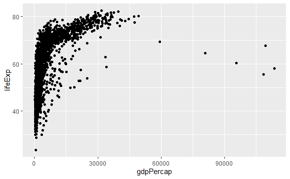

```r
library(ggplot2)
ggplot(data=gapminder) +
  geom_point(aes(x=gdpPercap, y = lifeExp))
```

Looks logarithmic. This makes sense (why?) Let’s use a logarithmic scale for x:

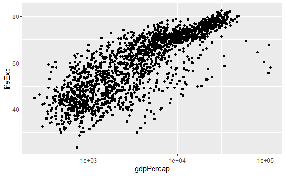

```r
ggplot(data=gapminder) +
  geom_point(aes(x=gdpPercap, y = lifeExp)) +
  scale_x_log10()
```

Awesome! It looks like we do have a linear relationship between (log) gdpPercap and lifeExp. But how can we test this hypothesis statistically?

### Question 1

Can we just run a regression $LifeExp = \beta_0+\beta_1 gdpPercap + \beta_2 pop + \epsilon$?

Why or why not?

Answer first. Then, continue reading. Spoilers ahead :)

A country’s wealth and population are not the only thing that can affect a country’s life expectancy. In fact, there are many other variables that can affect life expectancy, such as a country’s dietary habits, social welfare, air polution etc.

We do not have such data and, in fact, some of these variables may not even be observable. So we cannot put these variables into our regression. However, omitting relevant variables can lead to _______.

### Question 2

What are the consequences of ommiting a relevant variable from our regression model?

In classical regression, all data points are independent. In panel data, however, there are groups of datapoints that belong to the same country, and groups of datapoints that belong to the same year. As we’ll see throughout our course, observing the same countries throughout time can help us estimate the impact of gdpPercapita on Life Expectancy even though we lack many other relevant variables.

This means that in our previous scatter plot, the points are not really independent. Some of them belong to the same country, but in different years. In other words, we’re not observing a set of points, but a set of time series. Let’s visualize that:

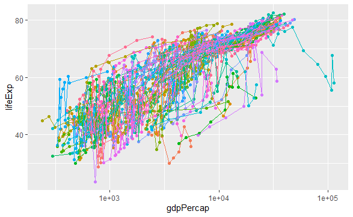

```r
ggplot(data=gapminder) +
  geom_point(aes(x=gdpPercap, y = lifeExp, color=country), show.legend = FALSE) +
  geom_line(aes(x=gdpPercap, y = lifeExp, color = country), show.legend = FALSE) +
  scale_x_log10()
```

It looks a bit confusing because there are many countries shown at once. Let me pick a few countries and show them to you. Yes, I’m cherrypicking, but it’s for teaching purposes, so I’m excused.

Let’s start by lookng at three developped countries: Canada, United States and France

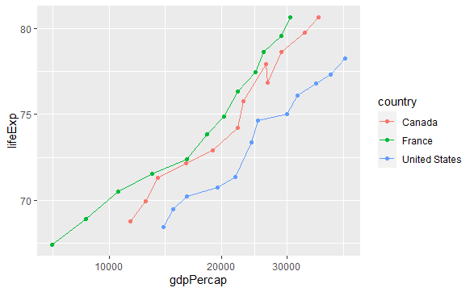

```r
library(dplyr)
sample_countries <- c("Canada","United States","France")
gapminder_sample <- gapminder %>% filter(country %in% sample_countries)

ggplot(data = gapminder_sample) +
  geom_point(aes(y=lifeExp, x = gdpPercap, color=country),show.legend = TRUE)+
  geom_line(aes(y=lifeExp, x = gdpPercap, color=country),show.legend = TRUE) +
  scale_x_log10()
```

All countries exhibit a positive relationship between wealth and life expectancy. But France seems to have higher life expectancy than Canada which, in turn, has better life expectancy than the US. This seems fairly constant through time.

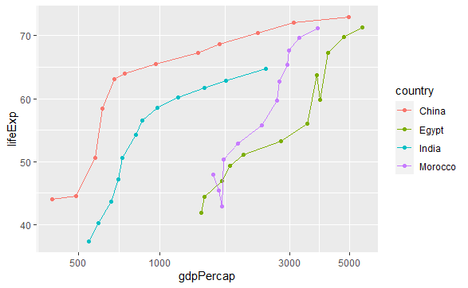

```r
sample_countries <- c("China","India","Egypt","Morocco")
gapminder_sample <- gapminder %>% filter(country %in% sample_countries)

ggplot(data = gapminder_sample) +
  geom_point(aes(y=lifeExp, x = gdpPercap, color=country),show.legend = TRUE)+
  geom_line(aes(y=lifeExp, x = gdpPercap, color=country),show.legend = TRUE) +
  scale_x_log10()
```

Here again, while all countries exhibit a positive relationship between life expectancy and gdp per capita, the curves seem to be positioned differently for each country. Something in the country positions the curve one place or another. In the case of India and China, these curves are almost parallel.

What are we seeing here? Why are some curves higher up, and others lower down?

What we’re seeing is the effect of the unobserved heterogeneity. We don’t know what it is, and it is likely a combination of factors: dietary habits, social welfare, environmental legislation…. but while we cannot see these variables individually, we see their effect, shifting some curves upwards and others downwards.

Suppose we simply ignore all this and run a regression. Mathematically, we can:

```r
library(stargazer)
ols <- lm(lifeExp ~ log(gdpPercap) + log(pop), data = gapminder)


stargazer(ols,
          type='text',
          object.names = TRUE,
          model.names = FALSE,
          model.numbers = FALSE)
```

[output not shown]

```
===============================================
                        Dependent variable:
                    ---------------------------
                              lifeExp
                                ols
-----------------------------------------------
log(gdpPercap)               8.344***
                              (0.143)

log(pop)                     1.279***
                              (0.111)

Constant                    -28.771***
                              (2.076)

-----------------------------------------------
Observations                   1,704
R2                             0.677
Adjusted R2                    0.677
Residual Std. Error      7.340 (df = 1701)
F Statistic         1,786.413*** (df = 2; 1701)
===============================================
Note:               *p<0.1; **p<0.05; ***p<0.01
```

In fact, this is what pooled regression does. It ignores the existance of unobserved heterogeneity and treats all data points as independent. Let’s run a pooled regression using the Panel Data package in R and show that its results match those of the classical regression we ran above:

```r
library(plm)

#Transform the data into a panel data dataframe
gapminder_pd <- pdata.frame(gapminder, index=c("country","year"))

#Ruun pooled regression
pooled <- plm(lifeExp ~ log(gdpPercap) + log(pop), data = gapminder_pd, model='pooling')

#Show results
stargazer(ols,
          pooled,
          type='text',
          object.names = TRUE,
          model.names = FALSE,
          model.numbers = FALSE)
```

[output not shown]

```
=========================================================
                                Dependent variable:
                           ------------------------------
                                      lifeExp
                                  ols           pooled
---------------------------------------------------------
log(gdpPercap)                 8.344***        8.344***
                                (0.143)        (0.143)

log(pop)                       1.279***        1.279***
                                (0.111)        (0.111)

Constant                      -28.771***      -28.771***
                                (2.076)        (2.076)

---------------------------------------------------------
Observations                     1,704          1,704
R2                               0.677          0.677
Adjusted R2                      0.677          0.677
Residual Std. Error        7.340 (df = 1701)
F Statistic (df = 2; 1701)   1,786.413***    1,786.413***
=========================================================
Note:                         *p<0.1; **p<0.05; ***p<0.01
```

If a graphical analysis won’t satisfy us and we wish to support this intuition by a propper statistical test, we can use the Breusch-Pagan test:

```r
plmtest(lifeExp ~ log(gdpPercap) + log(pop), data = gapminder_pd, type='bp')
```

```
    Lagrange Multiplier Test - (Breusch-Pagan) for
    balanced panels

data:  lifeExp ~ log(gdpPercap) + log(pop)
chisq = 2770.3, df = 1, p-value < 2.2e-16
alternative hypothesis: significant effects
```

The Breusch-Pagan test rejects the hypothesis that there are no unobserved heterogeneities, thus rejecting the pooled regression model.

The natural question to ask, then, is what model should we try next. The alternative hypothesis os the Breusch-Pagan test is that we should try a Random Effects model.

So lets do that and compare the results with those of the pooled regression:

```r
re <- plm(lifeExp ~ log(gdpPercap) + log(pop), data = gapminder_pd, model='random')

stargazer(re,
          ols,
          type='text',
          object.names = TRUE,
          model.names = FALSE,
          model.numbers = FALSE)
```

[output not shown]

```
============================================================
                              Dependent variable:
                    ----------------------------------------
                                    lifeExp
                         re                  ols
------------------------------------------------------------
log(gdpPercap)        6.719***            8.344***
                      (0.220)              (0.143)

log(pop)              7.601***            1.279***
                      (0.224)              (0.111)

Constant            -115.178***          -28.771***
                      (3.355)              (2.076)

------------------------------------------------------------
Observations           1,704                1,704
R2                     0.662                0.677
Adjusted R2            0.662                0.677
Residual Std. Error                   7.340 (df = 1701)
F Statistic         3,334.127*** 1,786.413*** (df = 2; 1701)
============================================================
Note:                            *p<0.1; **p<0.05; ***p<0.01
```

Coefficients are substantially different. Remarkably, population seems to have become much more relevant. Why so? Because by omitting relevant variables, the pooled regression coefficients were **biased**. The difference we see in coefficients values are the manifestation of this bias.

This does not mean that the coefficients estimated by the Random Effects models are unbiased. But it does set the stage for the other models we’ll see throughout the course.